# Quang’s IODS coursework

Nguyen Minh Quang

# About the course

This course is about how to process open data with R.

# Chapter 1 Setting up

## Summary

- Installed RStudio, Github
- Learned the basic R codes from DataCamp “R Short and Sweet”
- Github
  - Fork a project from: https://github.com/TuomoNieminen/IODS-project. This will go to my own repository under my own profile
  - enabled a web page which combines my weekly exercises (index.html). This is my course diary web page
  - make changes to the local copy and push the changes into remote GitHub repository. “Commit to master” often and even on small changes
  - finally, sync

## R Markdown

When I click the **Knit** button a document will be generated that includes both content as well as the output of any embedded R code chunks within the document. I can embed an R code chunk like this:

```r
summary(cars)
```

```
##      speed           dist
##  Min.   : 4.0   Min.   :  2.00
##  1st Qu.:12.0   1st Qu.: 26.00
##  Median :15.0   Median : 36.00
##  Mean   :15.4   Mean   : 42.98
##  3rd Qu.:19.0   3rd Qu.: 56.00
##  Max.   :25.0   Max.   :120.00
```

## Including Plots

I can also embed plots, for example:

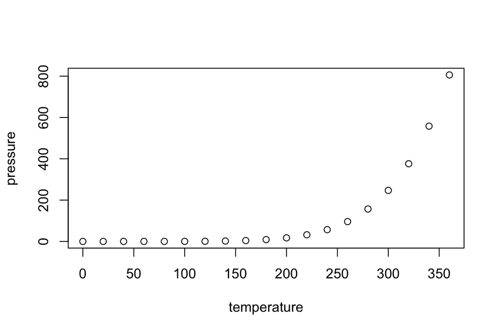

Tables

| First Header | Second Header |
| --- | --- |
| Content Cell | Content Cell |
| Content Cell | Content Cell |

Blockquotes

A friend once said:

> The only thing can stop a bad guy with a gun is a good guy with a gun

# Chapter 2: Regression and model validation

## Overview

The data “learning2014” explores the relationship between learning approaches and grades of students.

The learning approaches are divided in three categories:

1. deep learning
2. surface learning
3. strategic learning

“learning2014” contains 166 observations and 7 variables: age, attitude, gender, learning aprroaches (deep = deep, surface = surf and strategic = stra) and students’ grades (=points).

```
## 'data.frame':    166 obs. of  7 variables:
##  $ gender  : Factor w/ 2 levels "F","M": 1 2 1 2 2 1 2 1 2 1 ...
##  $ Age     : int  53 55 49 53 49 38 50 37 37 42 ...
##  $ Attitude: int  37 31 25 35 37 38 35 29 38 21 ...
##  $ deep    : num  3.58 2.92 3.5 3.5 3.67 ...
##  $ stra    : num  3.38 2.75 3.62 3.12 3.62 ...
##  $ surf    : num  2.58 3.17 2.25 2.25 2.83 ...
##  $ Points  : int  25 12 24 10 22 21 21 31 24 26 ...
```

```
## [1] 166   7
```

## Graphical overview

The graph below gives hints of correlations between variables. According to the graph, it seems that there are rather little correlations between the learning approaches, gender and age with the exam points. Contrary, the strongest correlation is between atttitude and points.

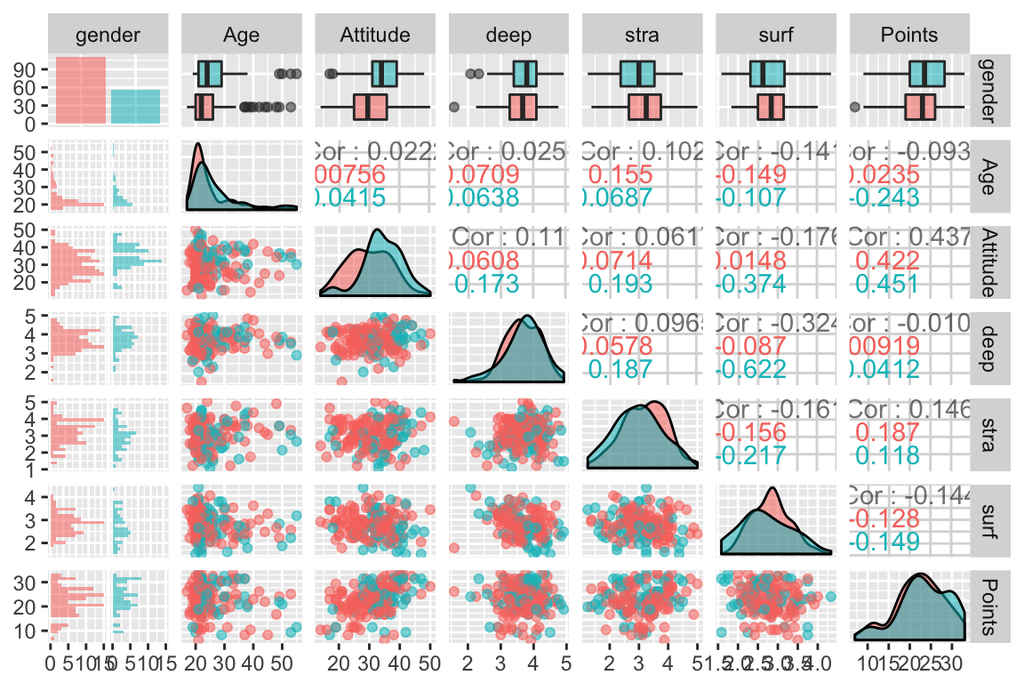

Several things we can tell from these graphs: - Male scores slightly higher than female students, but the range is wider - Attitude strongly correlates with grades - About learning stragies: + Stragic learning has a positive impact on grade + Surface learning has a negative impact on grade + Deep learning doesn’t have much impact on grade, the relationship is negative though

## Variable overview

gender: 110 female and 56 male students.

```
##   F   M
## 110  56
```

age: the youngest respondents is 17-year-old, and oldest 55-year-old, mean age being 25,5-year-old. Age is not normally distributed since there are more young students than old ones. The rest of our variables are normally distributed.

```
##    Min. 1st Qu.  Median    Mean 3rd Qu.    Max.
##   17.00   21.00   22.00   25.51   27.00   55.00
```

Attitude towards statistics: the attitude is shown in likert-scale 1-5.

```
##    Min. 1st Qu.  Median    Mean 3rd Qu.    Max.
##   1.400   2.600   3.200   3.143   3.700   5.000
```

Learning approaches (deep, strategic and surface) are each measusered in likert-scale 1-5:

deep learning approach:

```
##    Min. 1st Qu.  Median    Mean 3rd Qu.    Max.
##   1.583   3.333   3.667   3.680   4.083   4.917
```

strategic learning approach:

```
##    Min. 1st Qu.  Median    Mean 3rd Qu.    Max.
##   1.250   2.625   3.188   3.121   3.625   5.000
```

surface learning approach:

```
##    Min. 1st Qu.  Median    Mean 3rd Qu.    Max.
##   1.583   2.417   2.833   2.787   3.167   4.333
```

Exam points: min = 7 and the max = 33 points. Median value is approximately 23.

```
##    Min. 1st Qu.  Median    Mean 3rd Qu.    Max.
##    7.00   19.00   23.00   22.72   27.75   33.00
```

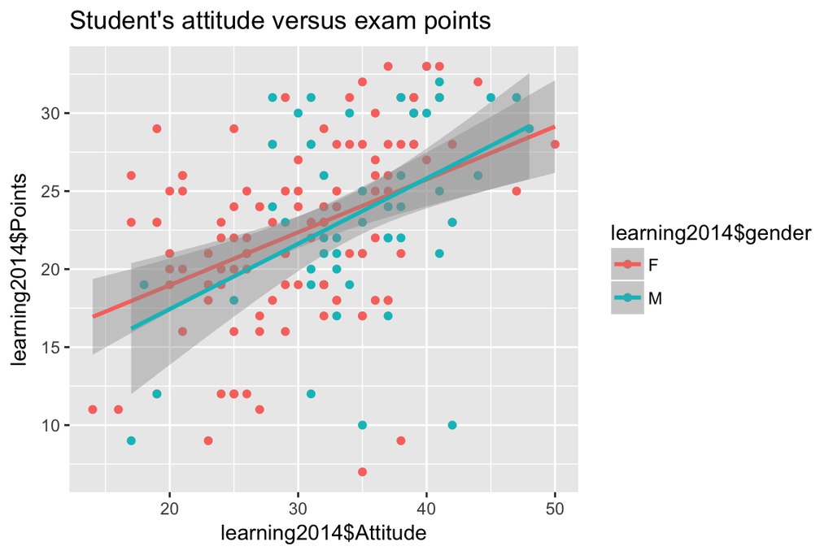

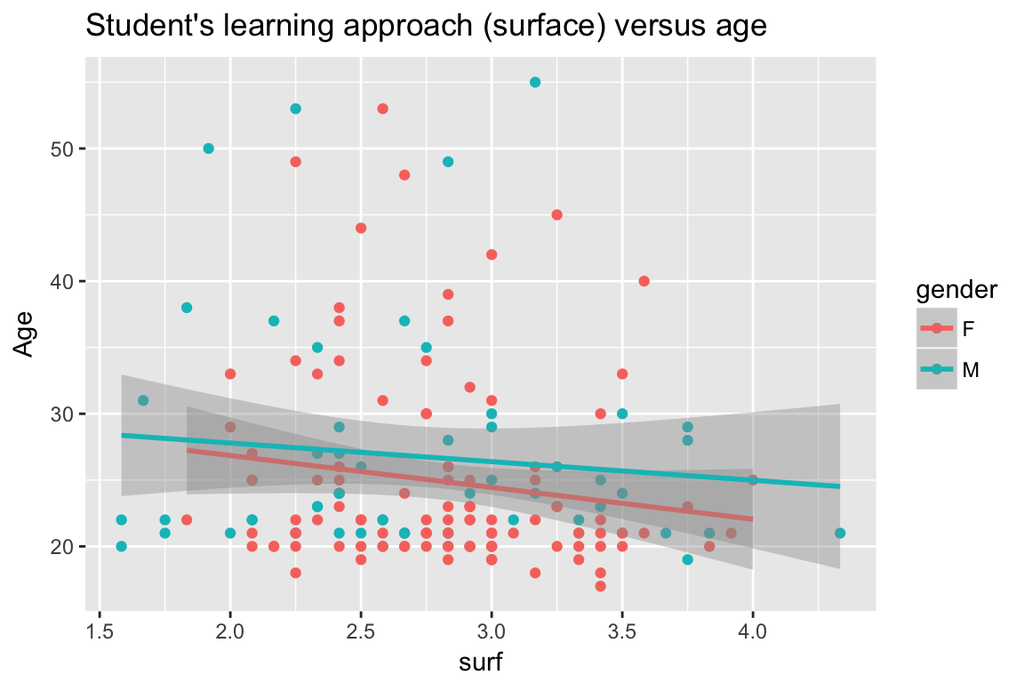

From the plot it seems attitude has a strong positive relationship with scores, while age has slightly negative relationship.

## Regression analysis

Model1 (below) shows the effects of attitude, strategic learning and surface learning on exam grades:

```
##
## Call:
## lm(formula = Points ~ Attitude + stra + surf, data = learning2014)
##
## Residuals:
##      Min       1Q   Median       3Q      Max
## -17.1550  -3.4346   0.5156   3.6401  10.8952
##
## Coefficients:
##             Estimate Std. Error t value Pr(>|t|)
## (Intercept) 11.01711    3.68375   2.991  0.00322 **
## Attitude     0.33952    0.05741   5.913 1.93e-08 ***
## stra         0.85313    0.54159   1.575  0.11716
## surf        -0.58607    0.80138  -0.731  0.46563
## ---
## Signif. codes:  0 '***' 0.001 '**' 0.01 '*' 0.05 '.' 0.1 ' ' 1
##
## Residual standard error: 5.296 on 162 degrees of freedom
## Multiple R-squared:  0.2074, Adjusted R-squared:  0.1927
## F-statistic: 14.13 on 3 and 162 DF,  p-value: 3.156e-08
```

Since “stra” and “surf” don’t have statistically significant impact on grades, we gonna exclude them from model1:

```r
model2 <- lm(Points ~ Attitude, data = learning2014)
summary(model2)
```

```
##
## Call:
## lm(formula = Points ~ Attitude, data = learning2014)
##
## Residuals:
##      Min       1Q   Median       3Q      Max
## -16.9763  -3.2119   0.4339   4.1534  10.6645
##
## Coefficients:
##             Estimate Std. Error t value Pr(>|t|)
## (Intercept) 11.63715    1.83035   6.358 1.95e-09 ***
## Attitude     0.35255    0.05674   6.214 4.12e-09 ***
## ---
## Signif. codes:  0 '***' 0.001 '**' 0.01 '*' 0.05 '.' 0.1 ' ' 1
##
## Residual standard error: 5.32 on 164 degrees of freedom
## Multiple R-squared:  0.1906, Adjusted R-squared:  0.1856
## F-statistic: 38.61 on 1 and 164 DF,  p-value: 4.119e-09
```

## Model Validation

Plots: (1) Residuals vs Fitted values, (2) Normal QQ-plot and (3) Residuals vs Leverage.

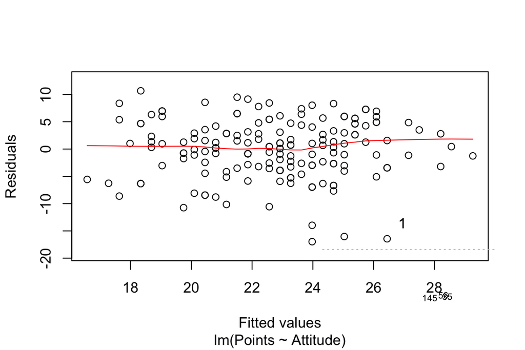

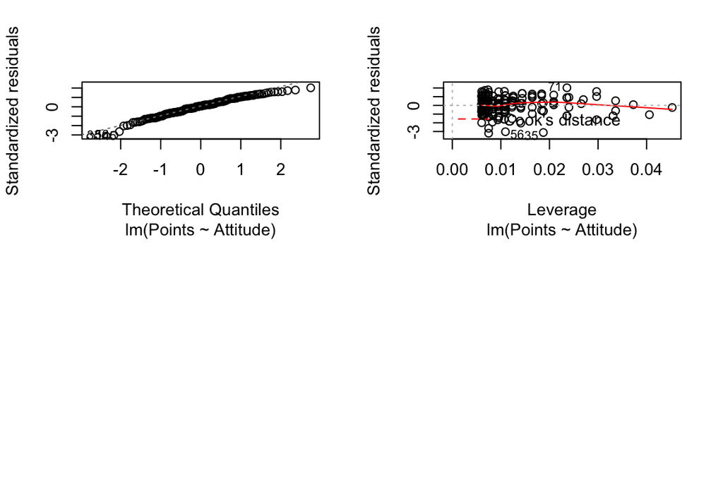

From the graph:

- Residuals vs Fitted values plot shows a symmetrical pattern. Our model is good then.
- Normal QQ-plot Plot shows that residuals are lined well on the straight dashed line, which means that they are quite normally distributed.
- Residual vs leverage plot shows possible influential cases. Levarage plot shows that there is no influential case, and we can be more confident with our model.

# Chapter3: Logistic Regression

```
##  [1] "school"     "sex"        "age"        "address"    "famsize"
##  [6] "Pstatus"    "Medu"       "Fedu"       "Mjob"       "Fjob"
## [11] "reason"     "nursery"    "internet"   "guardian"   "traveltime"
## [16] "studytime"  "failures"   "schoolsup"  "famsup"     "paid"
## [21] "activities" "higher"     "romantic"   "famrel"     "freetime"
## [26] "goout"      "Dalc"       "Walc"       "health"     "absences"
## [31] "G1"         "G2"         "G3"         "alc_use"    "high_use"
```

```
## 'data.frame':    382 obs. of  35 variables:
##  $ school    : Factor w/ 2 levels "GP","MS": 1 1 1 1 1 1 1 1 1 1 ...
##  $ sex       : Factor w/ 2 levels "F","M": 1 1 1 1 1 2 2 1 2 2 ...
##  $ age       : int  18 17 15 15 16 16 16 17 15 15 ...
##  $ address   : Factor w/ 2 levels "R","U": 2 2 2 2 2 2 2 2 2 2 ...
##  $ famsize   : Factor w/ 2 levels "GT3","LE3": 1 1 2 1 1 2 2 1 2 1 ...
##  $ Pstatus   : Factor w/ 2 levels "A","T": 1 2 2 2 2 2 2 1 1 2 ...
##  $ Medu      : int  4 1 1 4 3 4 2 4 3 3 ...
##  $ Fedu      : int  4 1 1 2 3 3 2 4 2 4 ...
##  $ Mjob      : Factor w/ 5 levels "at_home","health",..: 1 1 1 2 3 4 3 3 4 3 ...
##  $ Fjob      : Factor w/ 5 levels "at_home","health",..: 5 3 3 4 3 3 3 5 3 3 ...
##  $ reason    : Factor w/ 4 levels "course","home",..: 1 1 3 2 2 4 2 2 2 2 ...
##  $ nursery   : Factor w/ 2 levels "no","yes": 2 1 2 2 2 2 2 2 2 2 ...
##  $ internet  : Factor w/ 2 levels "no","yes": 1 2 2 2 1 2 2 1 2 2 ...
##  $ guardian  : Factor w/ 3 levels "father","mother",..: 2 1 2 2 1 2 2 2 2 2 ...
```

[output cut: 21 more lines]

## Hypotheses

To study possible factors that might have relationship with high/low alcohol consumption, we selected four variables: sex, goout, absences and studytime.

### sex

- H0: there is no relationship between high_use and sex
- H1: there is a relationship between high_use and sex

```
## Source: local data frame [4 x 3]
## Groups: high_use [?]
##
##   high_use    sex count
##      <lgl> <fctr> <int>
## 1    FALSE      F   156
## 2    FALSE      M   112
## 3     TRUE      F    42
## 4     TRUE      M    72
```

Result above shows students of both sexes have low alcohol consumption, but males’s consumption (72/184) are much higher than that in females (42/198). This support the alternative hypothesis.

### goout

- H0: there is no relationship between high_use and goout
- H1: there is a relationship between high_use and goout

```
## Source: local data frame [10 x 3]
## Groups: high_use [?]
##
##    high_use goout count
##       <lgl> <int> <int>
## 1     FALSE     1    19
## 2     FALSE     2    84
## 3     FALSE     3   103
## 4     FALSE     4    41
## 5     FALSE     5    21
## 6      TRUE     1     3
## 7      TRUE     2    16
## 8      TRUE     3    23
## 9      TRUE     4    40
## 10     TRUE     5    32
```

Result above indicates that students go out more also have higher rate of using alcohol. This support the alternative hypothesis.

### absences

- H0: there is no relationship between high_use and absences
- H1: there is a relationship between high_use and absences

```
## # A tibble: 2 × 3
##   high_use count mean_absences
##      <lgl> <int>         <dbl>
## 1    FALSE   268      3.705224
## 2     TRUE   114      6.368421
```

Result above suggests that high users having more absences. This support the alternative hypothesis.

### studytime

- H0: there is no relationship between high_use and studytime
- H1: there is a relationship between high_use and studytime

```
## # A tibble: 2 × 3
##   high_use count mean_weekly_study_time
##      <lgl> <int>                  <dbl>
## 1    FALSE   268               2.149254
## 2     TRUE   114               1.771930
```

Result above also sugggest that students are spent more time study are less likely to consume alcohol. This support the alternative hypothesis that there is a relationship between 2 variables, but it is a negative one.

## Logistic Regression and odds ratios

```
##
## Call:
## glm(formula = high_use ~ absences + studytime + goout + sex,
##     family = "binomial", data = alc)
##
## Deviance Residuals:
##     Min       1Q   Median       3Q      Max
## -1.9103  -0.7892  -0.5021   0.7574   2.6021
##
## Coefficients:
##             Estimate Std. Error z value Pr(>|z|)
## (Intercept) -3.20483    0.59429  -5.393 6.94e-08 ***
## absences     0.07811    0.02244   3.481 0.000499 ***
## studytime   -0.42116    0.17058  -2.469 0.013551 *
## goout        0.72677    0.11994   6.059 1.37e-09 ***
## sexM         0.78173    0.26555   2.944 0.003242 **
## ---
## Signif. codes:  0 '***' 0.001 '**' 0.01 '*' 0.05 '.' 0.1 ' ' 1
##
## (Dispersion parameter for binomial family taken to be 1)
##
##     Null deviance: 465.68  on 381  degrees of freedom
## Residual deviance: 381.31  on 377  degrees of freedom
## AIC: 391.31
##
## Number of Fisher Scoring iterations: 4
```

```
## (Intercept)    absences   studytime       goout        sexM
## -3.20483157  0.07810746 -0.42116184  0.72676824  0.78173290
```

```
##                     OR      2.5 %    97.5 %
## (Intercept) 0.04056573 0.01222314 0.1263579
## absences    1.08123884 1.03577383 1.1324143
## studytime   0.65628388 0.46510383 0.9099505
## goout       2.06838526 1.64470314 2.6349716
## sexM        2.18525582 1.30370562 3.7010763
```

- All variables except studytime (p-value < 0.05) are statistically significant with p-value < 0.01:
  - Students who have more absences are 1.08 times more likely to high_use.
  - Those who study more are 0.66 times less likely to high_use.
  - Those who go out more often are 2.1 times more likely to high_use.
  - Males are 2.2 times more likely to high_use than females.

## Predictive power, training error and cross-validation

```
##
## Call:
## glm(formula = high_use ~ absences + goout + sex, family = "binomial",
##     data = alc)
##
## Deviance Residuals:
##     Min       1Q   Median       3Q      Max
## -1.7871  -0.8153  -0.5446   0.8357   2.4740
##
## Coefficients:
##             Estimate Std. Error z value Pr(>|z|)
## (Intercept) -4.16317    0.47506  -8.764  < 2e-16 ***
## absences     0.08418    0.02237   3.764 0.000167 ***
## goout        0.72981    0.11970   6.097 1.08e-09 ***
## sexM         0.95872    0.25459   3.766 0.000166 ***
## ---
## Signif. codes:  0 '***' 0.001 '**' 0.01 '*' 0.05 '.' 0.1 ' ' 1
##
## (Dispersion parameter for binomial family taken to be 1)
##
##     Null deviance: 465.68  on 381  degrees of freedom
## Residual deviance: 387.75  on 378  degrees of freedom
## AIC: 395.75
##
## Number of Fisher Scoring iterations: 4
```

```
##         prediction
## high_use FALSE TRUE
##    FALSE   253   15
##    TRUE     65   49
```

```
##         prediction
## high_use      FALSE       TRUE        Sum
##    FALSE 0.66230366 0.03926702 0.70157068
##    TRUE  0.17015707 0.12827225 0.29842932
##    Sum   0.83246073 0.16753927 1.00000000
```

```
## [1] 0.2094241
```

```
## [1] 0.2251309
```

Training error of the model is 0.21, and by 10-fold cross-validation, the test error is approximately 0.22, lower than that in Datacamp (0.26)